# CptS-483-06

### **ARCH model**

Sometimes the series will exhibits periods of increased variability, sometimes called $volatility$. In order to account for volatility, we require a model that allows for conditional changes in the variance. One approach to this is to use an autoregressive model for the variance process. This leads to the ARCH(1) model, which considers the first-order autoregressive conditional heteroskedastic.

In R, we need to use the **garch()** function for ARCH model, and we need the library(tseries)

Recall the $ARIMA(1,1,1)$ model we have just used.

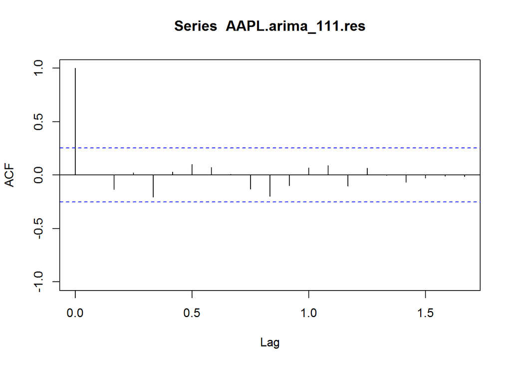

```r
AAPL.arima_111 <- arima(log(AAPL_monthly_last_five_data.ts), order=c(1,1,1), seas=list(order=c(0,0,0),12))
AAPL.arima_111.res <- resid(AAPL.arima_111)
acf(AAPL.arima_111.res, na.action=na.pass, ylim=c(-1,1), lag.max = 20)
```

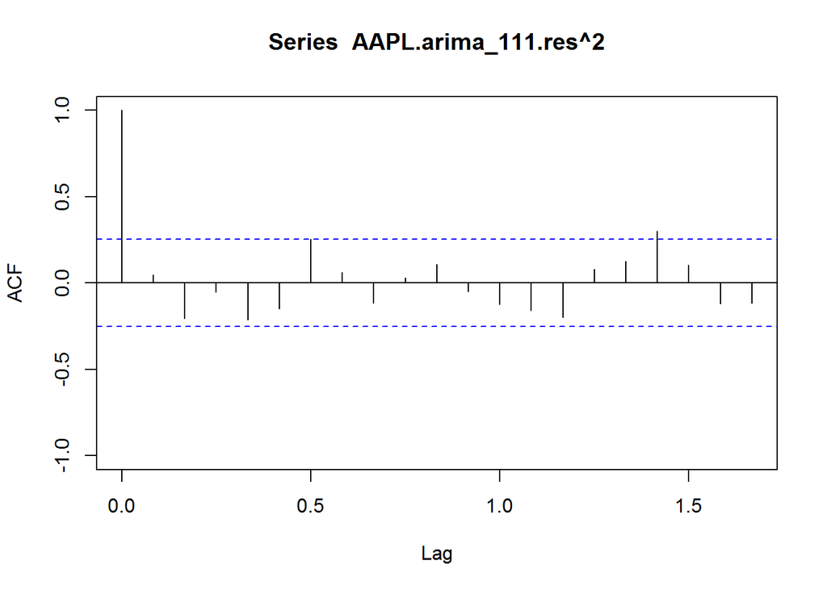

```r
acf(AAPL.arima_111.res^2, na.action=na.pass, ylim=c(-1,1), lag.max = 20)
```

There is clear evidence of volatility since the squared residuals are correlated at some lags. Hence, a GARCH model is fitted to the residual series

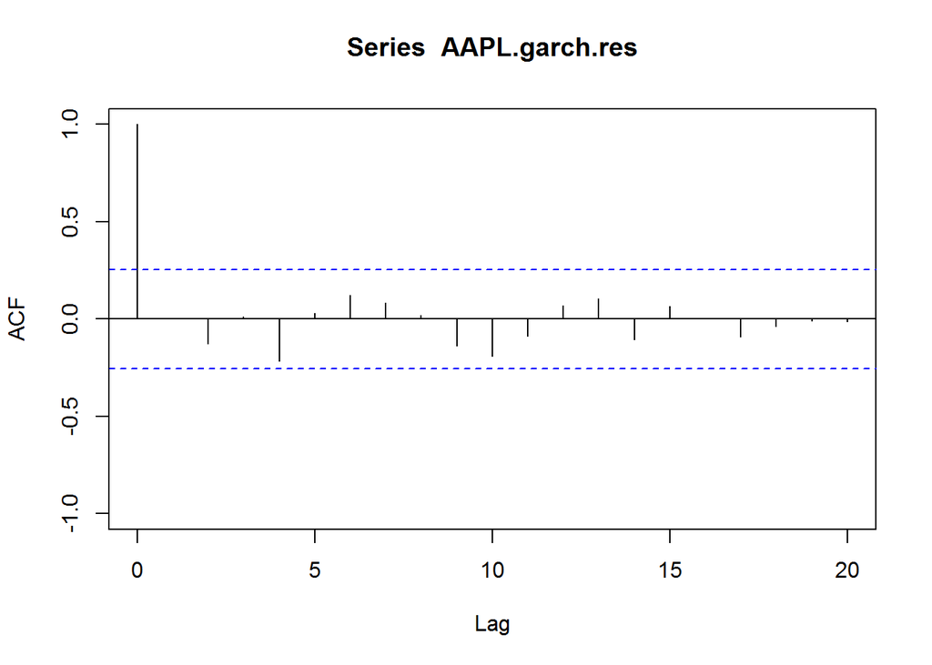

```r
library(tseries) # need this library for garch() method
AAPL.garch <- garch(AAPL.arima_111.res, trace =F)
AAPL.garch.res <- resid(AAPL.garch)[-1]
acf(AAPL.garch.res, na.action=na.pass, ylim=c(-1,1), lag.max=20)
```

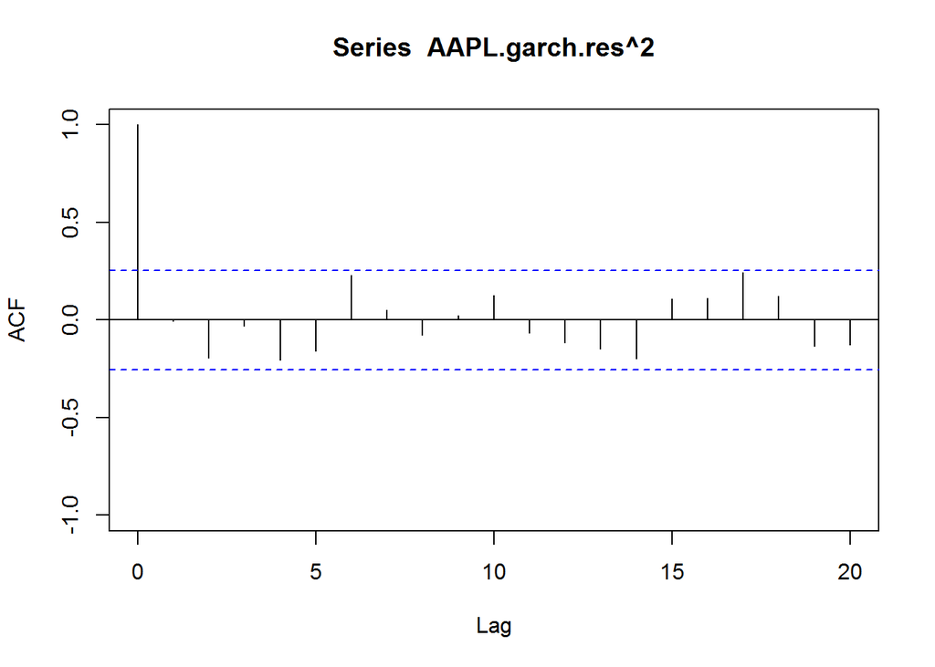

```r
acf(AAPL.garch.res^2, na.action=na.pass, ylim=c(-1,1), lag.max = 20)
```

Comparing the correlogram plots of ARIMA model and ARCH model, we can see that the ARCH mode performs better.

## **Prediction**

One of the principal goals with time series analysis is to produce predictions which show the future evolution of the data. This is what it is: an extrapolation in the time domain. And this is extremely important for finance. This is the main work for most stock traders at Wall street. And as we all know, extrapolation is always (at least slightly) problematic and can lead to false conclusions. Of course, this is no different with time series forecasting.

Here, we can perform some prediction based on the models we have got from the modeling section.

First,let us try the forcast based on the model $AR(1)$

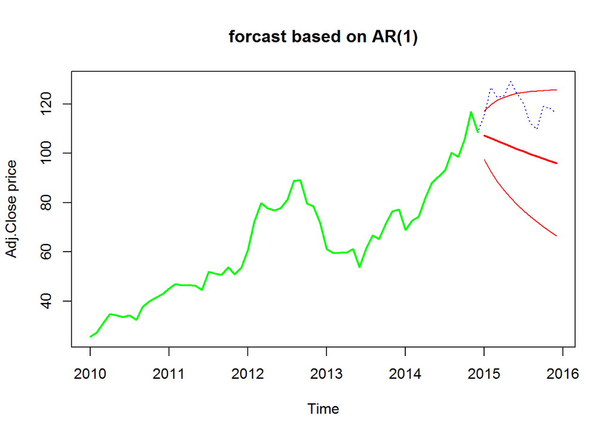

```r
last_five_data <- window(AAPL_monthly_last_six_data.ts, start=c(2010,1),end=c(2014,12))
fit <- ar.burg(last_five_data, order=1)
forecast <- predict(fit, n.ahead=12)
plot(AAPL_monthly_last_six_data.ts, lty=3, col="blue", main="forcast based on AR(1)", ylab="Adj.Close price", xlab="Time")
lines(last_five_data, lwd=2, col="green")
lines(forecast$pred, lwd=2, col="red")
lines(forecast$pred+forecast$se*1.96, col="red")
lines(forecast$pred-forecast$se*1.96, col="red")
```

As we can see, comparing the real trend and prediction region, the model doesn’t work very well.

Also we can try the model $AR(12)$

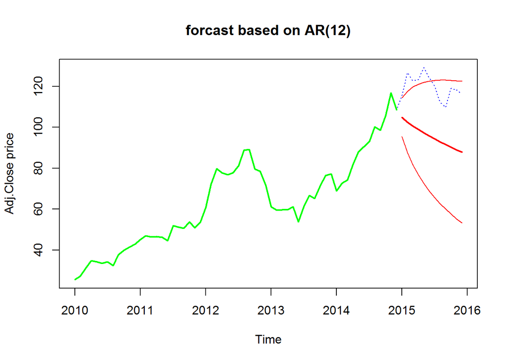

```r
last_five_data <- window(AAPL_monthly_last_six_data.ts, start=c(2010,1),end=c(2014,12))
fit <- ar.burg(last_five_data, order=12)
forecast <- predict(fit, n.ahead=12)
plot(AAPL_monthly_last_six_data.ts, lty=3, col="blue", main="forcast based on AR(12)", ylab="Adj.Close price", xlab="Time")
lines(last_five_data, lwd=2, col="green")
lines(forecast$pred, lwd=2, col="red")
lines(forecast$pred+forecast$se*1.96, col="red")
lines(forecast$pred-forecast$se*1.96, col="red")
```

Similarly, model $AR(12)$ doesn’t predict very well. It is kind of dispointed at this moment, after we have spent so many time to learn the previous models. However, it should make sense that the prediction is hard, otherwise everyone can easily make money from the stock market.

Finally let us try the ARIMA model. Before the prediction, I would like to introduce a simple function that can find the appropriate ARIMA model. Recall that in the modeling section, we just edit the command on each trial and find the smallest AIC model. Here, I introduce this function, which is in the book “Introductory Time Series with R”. This approach works better when the conditional sum of squares method CSS is selected in the arima function, as the algorithm is more robust.

```r
get.best.arima <- function(x.ts, maxord = c(1,1,1,1,1,1))
{
  best.aic <- 1e8
  n <- length(x.ts)
  for (p in 0:maxord[1]) for(d in 0:maxord[2]) for(q in 0:maxord[3])
    for (P in 0:maxord[4]) for(D in 0:maxord[5]) for(Q in 0:maxord[6])
    {
      fit <- arima(x.ts, order = c(p,d,q),
                   seas = list(order = c(P,D,Q),
                               frequency(x.ts)), method = "CSS")
      fit.aic <- -2 * fit$loglik + (log(n) + 1) * length(fit$coef)
      if (fit.aic < best.aic)
      {
        best.aic <- fit.aic
        best.fit <- fit
        best.model <- c(p,d,q,P,D,Q)
      }
    }
  list(best.aic, best.fit, best.model)
}
```

With this method, we can find the appropriate ARIMA parameters and then perform the prediction.

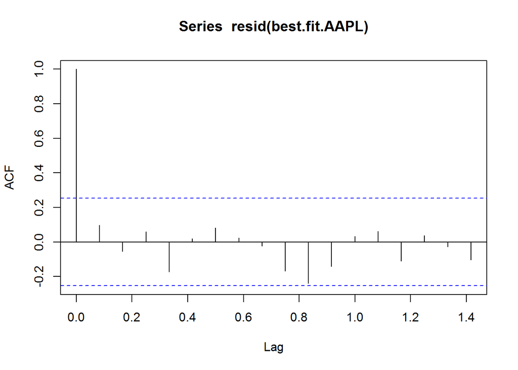

```r
best.arima.AAPL <- get.best.arima(AAPL_monthly_last_five_data.log.ts, maxord =c(2,2,2,1,1,1))
best.fit.AAPL <- best.arima.AAPL[[2]]
acf(resid(best.fit.AAPL))
```

```r
best.arima.AAPL[[3]]
```

```
## [1] 1 1 1 0 0 0
```

By setting different maxord(), we can get different ARIMA parameters.

$(2,2,2,1,1,1) => 1 1 1 0 0 0$ $(2,2,2,2,1,1) => 2 1 2 2 0 1$

Let us use the (1,1,1,0,0,0) model to perform the prediction.

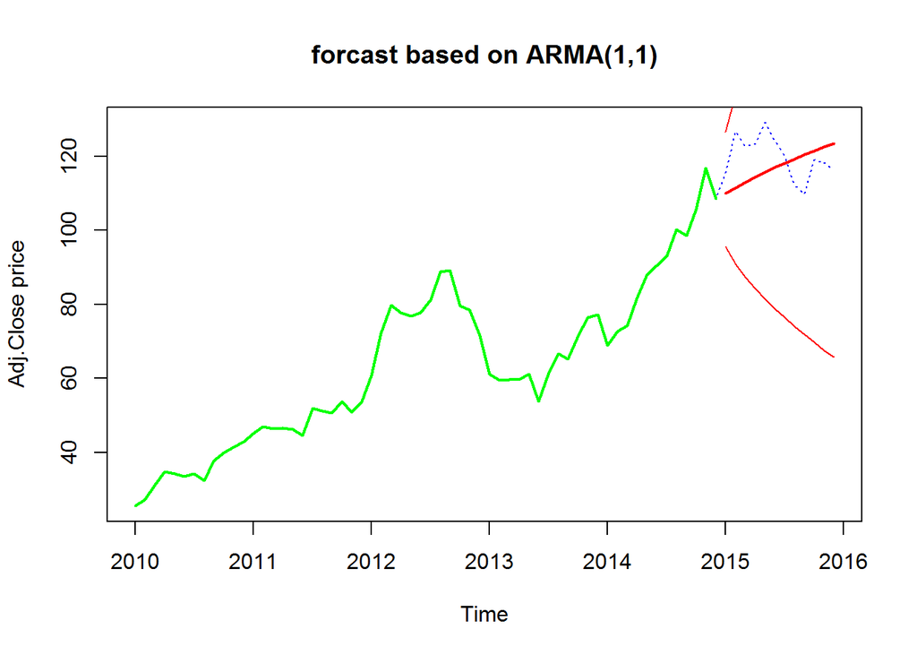

```r
last_five_data <- window(AAPL_monthly_last_six_data.ts, start=c(2010,1),end=c(2014,12))
fit <- best.fit.AAPL
forecast <- predict(fit, n.ahead=12)
plot(AAPL_monthly_last_six_data.ts, lty=3, col="blue", main="forcast based on ARMA(1,1)", ylab="Adj.Close price", xlab="Time")
lines(last_five_data, lwd=2, col="green")
lines(exp(forecast$pred), lwd=2, col="red")
lines(exp(forecast$pred+forecast$se*1.96), col="red")
lines(exp(forecast$pred-forecast$se*1.96), col="red")
```

From the result, we can see this is a little bit better than other models.

# **Machine Learning Based Modeling & Prediction**

We study the stock data in two aspects, **classification** and **regression**. For example, predicting the exact price of a stock is a regression problem, whereas predicting the trend labeled by UP or DOWN is a classification process.

Actually, predicting the exact price of a stock is super hard. Predicting the trend is also a very hard problem. Because the whole stock market is a huge dynamic system, which changes uncertainly with time. People are researching the stock market to find better models and methods for many years. Sometimes, these models or methods do not work properly because of the complexity of the stock market. But, interestingly, the finance industry always focuses on the future rather than dwell on the past.

Machine learning is a theory to study the historic data, train a descriptive mode and predict the future data. Powered by machine learning techniques, we can find something interesting in the past and give some indication for future decision.

## **Feature Selection**

The raw data from Yahoo finance is like below:

```r
tail(apple.stock)
```

```
##            Date   Open   High    Low  Close   Volume Adj.Close
## 6526 2015-11-20 119.20 119.92 118.85 119.30 34287100    119.30
## 6527 2015-11-23 119.27 119.73 117.34 117.75 32482500    117.75
## 6528 2015-11-24 117.33 119.35 117.12 118.88 42803200    118.88
## 6529 2015-11-25 119.21 119.23 117.92 118.03 21388300    118.03
## 6530 2015-11-27 118.29 118.41 117.60 117.81 13023700    117.81
## 6531 2015-11-30 117.99 119.41 117.75 118.30 37658700    118.30
```

First, we do some data cleaning (or say preparation), i.e., mark the time series (the Date) as integers, and give each attribute a name as features.

| Date | Open | High | Low | Close | Volume | Adj Close |
| --- | --- | --- | --- | --- | --- | --- |
| $n$ | $r$ | $s$ | $t$ | $u$ | $v$ | $w$ |

Then we design the groundtruth. For regression problem to fit the price, we just use the **Close** value $u$ as $y$. For the classification problem to predict the trend, use $u_n - u_{n-1} \ge 0$ as UP else as DOWN.

Additionally, we combine the raw data in any reasonable ways to make more features. Because sometimes the raw data is not fully intuitive to represent the problem. And it is easy to construct new features from existed features to increase the complexity of our prediction model. So our final feature vectors are like this:

$\left( Y, y, r, s, t, u, v, w, u^2, u^3 \dots u^6, v^2, v^3 \dots v^6, u^m v^n, u-r, s-t, (s-r)/r, (t-r)/r, (u-r)/r \right)$

Here $m, n \le 6$ are the orders of $u$ and $v$. Usually, the trend of Price $u$ is opposite to the trade Volume $v$. So calculating $u^m v^n$ is to find some correlation between the two variables. Intuitively, $u-r$ means the difference between two dates, and $s-t$ means what is the maximum of range in one date. $(s-r)/r, (t-r)/r$, and similarly $(u-r)/r$ are the relative amplitudes compared with the Open price in a date.

## **Experiments**

We take the experiments on the stock of Apple Inc. during the past 25 years, starting 1990-01-01 to 2015-11-30, totally 6531 daily examples, sampled monthly 311 examples. Totually, 52% of the data is positive data.. A set of machine learning algorithms are applied to both the raw and the feature-selected datasets on daily and monthly basis. The chosen machine learning algorithms for classification are Naive Bayes, Logistic Regression, KNN, AdaBoost, Bagging, Decision Trees, RandomForests, while for regression are linear regression. Then we have the prediction rate of each algorithm and compare the results.

## **Results**

The learning accuray of each learning algorithm is below:

```
##                  Data NaiveBayes Logistic     KNN AdaBoost Bagging
## 1 our_feature_monthly    67.5241  91.6399 87.7814  96.7846 95.8199
## 2   our_feature_daily    56.2854  85.7449 82.6520  85.2549 85.4234
## 3         raw_monthly    51.1254  95.4984 56.9132  61.7363 70.7395
## 4           raw_daily    51.4316  85.4387 58.5515  54.6318 72.4085
##   DecisionTrees RandomForests LinearRegression    RMSE
## 1       95.4984       96.4630           1.0000  0.0000
## 2       85.4234       85.3774           1.0000  0.0000
## 3       61.7363       75.8842           0.6531 24.3474
## 4       55.2136       74.5828           1.0000  1.2696
```

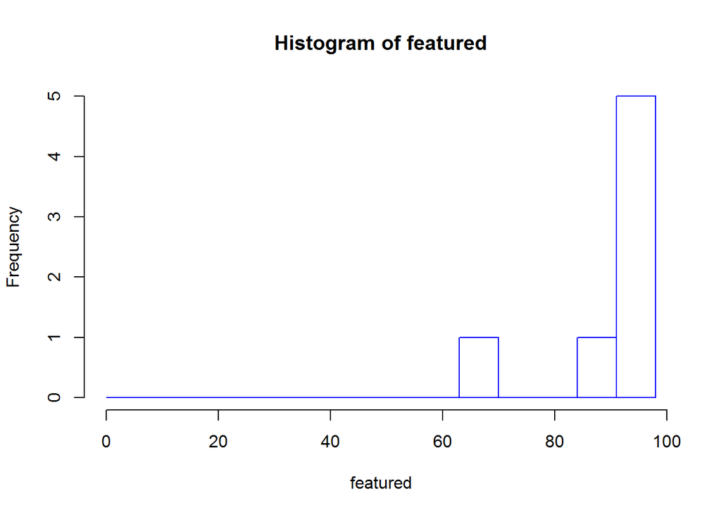

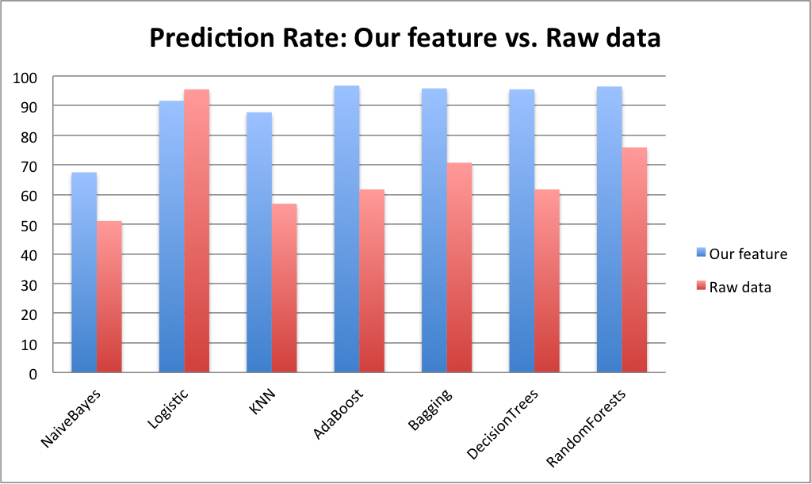

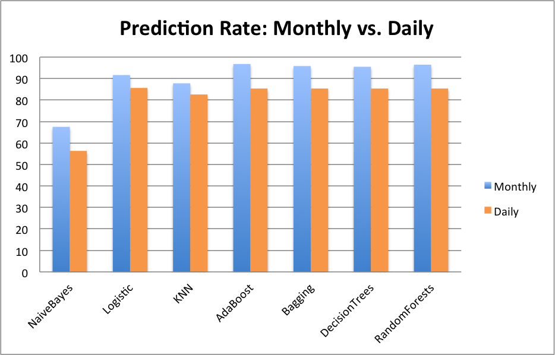

In conclusion, we can see the machine learning algorithms do help on the problems of stock prediction, both the stock price prediction and the trend prediction.

# **Summary & Conclusion**

We have studied the time series data modeling topic by looking at stock price in two ways. One is the traditional time series modeling. We have explored several different time series models and applied them on the stock price modeling and prediction. The other is the machine learning techniques. Time series modeling is to model the data first and then predict the data. On the contrary, machine learning techniques are in a computational manner, which is not to modeling at first.

In the process of this course project, we have learned how to doing data science to real world problem.

# **Resources & Tools**

## **The way doing data science**

Tools: all powered by Open Source Softwares

- Data Visualization: R, ts, quantmod
- Machine Learning: Weka
- Presentation: html5, pandoc, liquid
- Totally reproducible research

## **Books & Reference**

- Wes, McKinney. “Python for data analysis.” (2012).
- Cowpertwait, Paul SP, and Andrew V. Metcalfe. Introductory time series with R. Springer Science & Business Media, 2009.
- Dr. Marcel Dettling, Applied Time Series Analysis
- Schutt, Rachel, and Cathy O’Neil. Doing data science: Straight talk from the frontline. " O’Reilly Media, Inc.“, 2013.
- Zhao, Yanchang. R and data mining: Examples and case studies. Academic Press, 2012.
- Time Series Analysis with ARIMA - ARCH/GARCH model in R https://talksonmarkets.files.wordpress.com/2012/09/time-series-analysis-with-arima-e28093-arch013.pdf
- Time Series Analysis of Aviation Data http://catsr.ite.gmu.edu/SYST660/SYST660_Time_Series_Analysis_with_Aviation_Data.pdf
- R/Finance http://www.rinfinance.com/agenda/2012/workshop/